# LAScatalog formal class

A `LAScatalog` class is a representation in R of a las file or a collection of las files not loaded in memory. Indeed, a regular computer cannot load the entire point cloud in R if it covers a broad area. For very high density datasets it can even fail loading a single file (see also the “LAS formal class” vignette). In lidR, we use a `LAScatalog` to process datasets that cannot fit in memory.

## Build a LAScatalog object reading a folder of las files

```r
ctg <- readLAScatalog("path/to/las/files/")
# or
ctg <- readLAScatalog("path/to/las/files/big_file.las")
```

```r
ctg
```

```
#> class       : LAScatalog (v1.2 format 1)
#> extent      : 883166.1, 895250.2, 625793.6, 639938.4 (xmin, xmax, ymin, ymax)
#> coord. ref. : NAD83 / UTM zone 17N
#> area        : 111.1 km²
#> points      : 0  points
#> type        : unknown
#> density     : 0 points/m²
#> num. files  : 62
```

## Basic structure of a LAScatalog object

A `LAScatalog` contains a `sf` object with `POLYGON` geometries plus some extra slots that store information relative to how the `LAScatalog` will be processed.

The slot `data` of a `LAScatalog` object contains the `sf` object with the most important information read from the header of .las or .laz files. Reading only the header of the file provides an overview of the content of the files very quickly without actually loading the point cloud. The columns of the table are named after the [LAS specification](https://community.asprs.org/leadership-restricted/leadership-content/public-documents/standards) version 1.4

The other slots are well documented in the documentation `help("LAScatalog-class")` so they are not described in this vignette.

## Allowed and non-allowed manipulation of a LAScatalog object

A `LAScatalog` purpose is not to manipulate spatial data in R. The purpose of a `LAScatalog` is to represent a set of existing las/laz files. Thus a `LAScatalog` cannot be modified because it must be related to the actual content of the files. The following throws an error:

```r
ctg$Min.Z <- 0
```

```
#> Error: LAScatalog data read from standard files cannot be modified
```

Obviously it is always possible to modify an R object by bypassing such simple restrictions. In this case the user will break something internally and a correct output is not guaranteed.

However it is possible to add and modify the attributes using a name that is not reserved. The following is allowed:

```r
ctg$newattribute <- 0
```

## Validation of LAScatalog object

Users commonly report bugs arising from the fact that the point cloud is invalid. This is why we introduced the function `las_check()` to perform an inspection of the `LAScatalog` objects. This function checks if a `LAScatalog` object is consistent (files are all of the same type for example). For example, it may happen that a collection mixes files of type 1 with files of type 3 or files with different scale factors.

```r
las_check(ctg)
```

```
#>
#>  Checking headers consistency
#>   - Checking file version consistency... ✓
#>   - Checking scale consistency... ✓
#>   - Checking offset consistency... ✓
#>   - Checking point type consistency... ✓
#>   - Checking VLR consistency... ✓
#>   - Checking CRS consistency... ✓
#>  Checking the headers
#>   - Checking scale factor validity... ✓
#>   - Checking Point Data Format ID validity... ✓
#>  Checking preprocessing already done
#>   - Checking negative outliers...
#>     ⚠ 2 file(s) with points below 0
#>   - Checking normalization... no
#>  Checking the geometry
#>   - Checking overlapping tiles...
#>     ⚠ Some tiles seem to overlap each other
#>   - Checking point indexation... no
```

The function `las_check()` when applied to a `LAScatalog` does not perform a deep inspection of the point cloud unlike when applied to a `LAS` object. Indeed the point cloud is not actually read.

## Display a LAScatalog object

`lidR` provides a simple `plot()` function to plot a `LAScatalog` object:

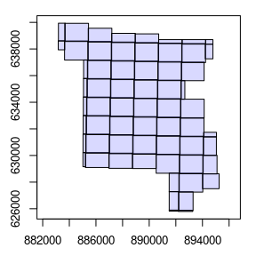

```r
plot(ctg)
```

The option `mapview = TRUE` displays the `LAScatalog` on an interactive map with pan and zoom and allows the addition of a satellite map in the background. It uses the package `mapview` internally. It is often useful to check if the CRS of the file are properly registered. The epsg codes recorded in the las files appear to be sometime incorrect, according to our own experience.

[figure not shown]

```r
plot(ctg, mapview = TRUE, map.type = "Esri.WorldImagery")
```

Using a `sf` object to store the attributes of the las file it is easy to display metadata of the files. In the following we can immediately see that the catalog is not normalized and is likely to contain outliers:

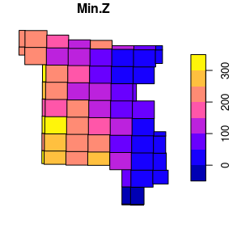

```r
plot(ctg["Min.Z"])
```

## Apply lidR functions on a LAScatalog

Most of lidR functions are compatible with a `LAScatalog` and work almost like with a single point cloud loaded in memory. In the following example we use the function `pixel_metrics()` to compute the mean elevation of the points. The output is a continuous wall-to-wall raster. It works exactly as if the input was a `LAS` object.

```r
hmean <- pixel_metrics(ctg, mean(Z), 20)
```

However, processing a `LAScatalog` usually requires some tuning of the processing options to get better control of the computation. Indeed, if the catalog is huge the output is likely to be huge as well, and maybe the output cannot fit in the R memory. For example, `normalize_height()` throws an error if used ‘as is’ without tuning the processing options. Using `normalize_height()` like in the following example the expected `output` would be a huge point cloud loaded in memory. The lidR package forbids such a call:

```r
output <- normalize_height(ctg, tin())
```

```
#> Error: This function requires that the LAScatalog provides an output file template.
```

Instead, one can use the processing option `opt_output_files()`. Processing options drive how the big files are split in small chunks and how the outputs are either returned into R or written on disk into files.

```r
opt_output_files(ctg) <- "folder/where/to/store/outputs/{ORIGINALFILENAME}_normalized"
output <- normalize_height(ctg, tin())
```

Here the output is not a point cloud but a `LAScatalog` pointing to the newly created files. The user can check how the collection will be processed by calling `summary`

```r
summary(ctg)
```

```
#> class       : LAScatalog (v1.2 format 1)
#> extent      : 883166.1, 895250.2, 625793.6, 639938.4 (xmin, xmax, ymin, ymax)
#> coord. ref. : NAD83 / UTM zone 17N
#> area        : 111.1 km²
#> points      : 0  points
#> type        : unknown
#> density     : 0 points/m²
#> num. files  : 62
#> proc. opt.  : buffer: 30 | chunk: 0
#> input opt.  : select: * | filter:
#> output opt. : in memory | w2w guaranteed | merging enabled
#> drivers     :
#>  - Raster : format = GTiff  NAflag = -999999
#>  - stars : NA_value = -999999
#>  - Spatial : overwrite = FALSE
#>  - SpatRaster : overwrite = FALSE  NAflag = -999999
#>  - SpatVector : overwrite = FALSE
#>  - LAS : no parameter
#>  - sf : quiet = TRUE
#>  - data.frame : no parameter
```

Also the `plot` function can displays the chunks pattern i.e. how the dataset is split into small chunks that will be sequentially processed

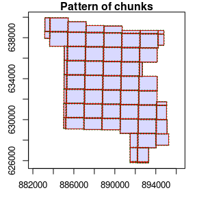

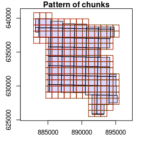

```r
opt_chunk_size(ctg) <- 0
plot(ctg, chunk = TRUE)

opt_chunk_size(ctg) <- 900
plot(ctg, chunk = TRUE)
```

## Partial processing

It possible to flag some file that will not be processed but that will be used to load a buffer if required. In the following example only the central files will be processed but the others one were not removed and they will be used to buffer the processed files.

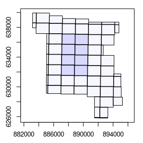

```r
ctg$processed <- FALSE
ctg$processed[c(19:20, 41:44, 49:50)] <- TRUE
plot(ctg)
```

## Some practical examples

#### Example 1 - Raster

Load a collection Process each file sequentially. Returns a raster into R.

```r
ctg <- readLAScatalog("path/to/las/files/")
hmean <- pixel_metrics(ctg, ~mean(Z), 20)
```

#### Example 2 - Raster

Load a collection Process each file sequentially. For each file write a raster on disk named after the name of the processed files. Returns a lightweight virtual raster mosaic.

```r
ctg <- catalog("path/to/las/files/")
opt_output_files(ctg) <- "folder/where/to/store/outputs/dtm_{ORIGINALFILENAME}"
dtm <- rasterize_terrain(ctg, tin())
```

#### Example 3 - Raster

Load a single big file too big to be actually loaded in memory. Process small chunks of 100 x 100 meters at a time. Returns a raster into R.

```r
ctg <- readLAScatalog("path/to/las/files/bigfile.las")
opt_chunk_size(ctg) <- 100
chm <- rasterize_canopy(ctg, p2r())
```

#### Example 4 - Tree detection

Load a collection. Process small chunks of 200 x 200 meters at a time. Each chunk is loaded with an extra 20 m buffer. Returns spatial points into R.

```r
ctg <- readLAScatalog("path/to/las/files/")
opt_chunk_size(ctg) <- 200
opt_chunk_buffer(ctg) <- 20
ttops <- locate_trees(ctg, lmf(5))
```

#### Example 5 - Decimate

This is forbidden. The output would be too big.

```r
ctg <- readLAScatalog("path/to/las/files/")
decimated <- decimate_points(ctg, homogenize(4))
```

#### Example 6 - Decimate

Load a collection. Process small chunks of 500 x 500 meter sequentially. For each chunk write a laz file on disk named after the coordinates of the chunk. Returns a lightweight `LAScatalog`. Note that the original collection has been retiled.

```r
ctg <- readLAScatalog("path/to/las/files/")
opt_chunk_size(ctg) <- 500
opt_output_files(ctg) <- "folder/where/to/store/outputs/project_{XLEFT}_{YBOTTOM}_decimated"
opt_laz_compression(ctg) <- TRUE
decimated <- decimate_points(ctg, homogenize(4))
```

#### Example 7 - Clip

Load a collection. Load a shapefile of plot centers. Extract the plots. Returns a list of extracted point clouds in R.

```r
ctg <- readLAScatalog("path/to/las/files/")
shp <- sf::st_read("plot_center.shp")
plots <- clip_roi(ctg, shp, radius = 11.2)
```

#### Example 8 - Clip

Load a collection. Load a shapefile of plot centers. Extract the plots and immediately write them into a file named after the coordinates of the plot and an attributes of the shapefile (here `PLOTID` if such an attribute exists in the shapefile). Returns a lightweight `LAScatalog`.

```r
ctg <- readLAScatalog("path/to/las/files/")
shp <- sf::st_read("plot_center.shp")
opt_output_files(ctg) <- "folder/where/to/store/outputs/plot_{XCENTER}_{YCENTER}_{PLOTID}"
plots <- clip_roi(ctg, plot_centers, radius = 11.2)
```